# Modeling and prediction for movies

## Setup

### Load packages

```r
library(ggplot2)
library(dplyr)
library(statsr)
library(GGally)
```

### Load data

```r
load("movies.Rdata")
```

## Part 1: Data

Random sampling was used, but the sample sources are only 2 sites: Rotten Tomatoes and IMDB  
Thus, this research result could be generalized to **a mainstream cinema production industry**,  
coming under the radar of those two mainstream movie data concentration sites.  
Many foreign/localized/niche/specific/amateur target audience films are not represented by this sample.  
Causality is out of scope. This is not a random assignment research with the control group.  
* * *

## Part 2: Research question

What makes a movie popular?  
Define what is “popular” in terms of available data.  
Using linear regression analysis assess available variables which could be used to predict a movie popularity.

## Part 3: Exploratory data analysis

General data observations:

```r
dim(movies)
```

```
## [1] 651  32
```

```r
names(movies)
```

```
##  [1] "title"            "title_type"       "genre"            "runtime"
##  [5] "mpaa_rating"      "studio"           "thtr_rel_year"    "thtr_rel_month"
##  [9] "thtr_rel_day"     "dvd_rel_year"     "dvd_rel_month"    "dvd_rel_day"
## [13] "imdb_rating"      "imdb_num_votes"   "critics_rating"   "critics_score"
## [17] "audience_rating"  "audience_score"   "best_pic_nom"     "best_pic_win"
## [21] "best_actor_win"   "best_actress_win" "best_dir_win"     "top200_box"
## [25] "director"         "actor1"           "actor2"           "actor3"
## [29] "actor4"           "actor5"           "imdb_url"         "rt_url"
```

### What response variable to consider?

Examine potential response variables, select ones that could be used to effectively assess a movie popularity.

Construct a general function that allows to inspect the response variable and its presence in the sample

```r
assess_variable<- function(assessed_variable){
  data_set_size<-0
  present<-0
  for (i in assessed_variable){
    if(!is.na(i)){
      present = present+1
    }
    data_set_size = data_set_size+1
  }

  subcats = unique(assessed_variable)
  uniquenames=length(subcats)
  assessment <- list("num_subcats" = uniquenames, "subcats" = subcats , "coverage" = present/data_set_size )

}
```

imdb_rating

```r
imdb_rating_assessment = assess_variable(movies$imdb_rating)
imdb_rating_assessment
```

```
## $num_subcats
## [1] 56
##
## $subcats
##  [1] 5.5 7.3 7.6 7.2 5.1 7.8 7.5 6.6 6.8 6.0 5.9 3.6 7.0 6.9 4.4 6.2 5.3 7.1 5.6
## [20] 6.4 7.9 7.7 6.5 6.1 8.4 7.4 5.4 6.7 2.7 6.3 8.5 8.1 5.7 8.2 5.8 8.0 4.1 3.8
## [39] 3.5 3.4 4.2 4.5 2.4 4.8 5.2 2.3 9.0 4.9 4.6 1.9 3.1 5.0 8.3 4.3 4.7 2.8
##
## $coverage
## [1] 1
```

audience_rating

```r
audience_rating_assessment = assess_variable(movies$audience_rating)
audience_rating_assessment
```

```
## $num_subcats
## [1] 2
##
## $subcats
## [1] Upright Spilled
## Levels: Spilled Upright
##
## $coverage
## [1] 1
```

audience_score

```r
audience_score_assessment = assess_variable(movies$audience_score)
audience_score_assessment
```

```
## $num_subcats
## [1] 84
##
## $subcats
##  [1] 73 81 91 76 27 86 47 89 66 75 46 53 36 64 80 92 24 19 42 71 77 41 43 61 85
## [26] 70 57 55 51 94 88 40 62 49 17 56 52 83 72 59 38 35 54 44 96 58 90 30 39 87
## [51] 34 14 82 25 74 93 37 33 45 48 69 78 65 67 79 63 84 22 50 32 68 11 31 21 29
## [76] 23 60 28 97 95 13 26 15 18
##
## $coverage
## [1] 1
```

### Create combined_score (to take into account IMDB and RT scores together)

```r
movies<-movies%>%
  mutate(combined_score=(imdb_rating*10+audience_score)/2)
```

```r
combined_score_assessment = assess_variable(movies$combined_score)
combined_score_assessment
```

```
## $num_subcats
## [1] 126
##
## $subcats
##   [1] 64.0 77.0 83.5 74.0 39.0 82.0 51.0 66.0 71.5 53.0 82.5 56.0 36.0 67.0 76.0
##  [16] 80.5 34.0 27.5 81.0 52.0 66.5 76.5 47.0 49.5 62.5 85.0 71.0 73.5 70.5 61.5
##  [31] 60.0 70.0 89.0 77.5 65.0 83.0 64.5 86.0 63.5 65.5 58.0 22.0 60.5 59.0 78.5
##  [46] 62.0 46.5 45.0 53.5 58.5 90.5 48.0 85.5 52.5 42.5 48.5 81.5 78.0 74.5 46.0
##  [61] 44.5 87.0 57.0 57.5 25.0 72.0 68.5 50.5 41.0 73.0 37.0 54.5 55.0 36.5 88.0
##  [76] 72.5 40.5 56.5 51.5 75.5 35.5 63.0 45.5 30.0 37.5 79.0 68.0 49.0 41.5 84.0
##  [91] 67.5 29.0 59.5 17.5 50.0 86.5 38.5 69.5 80.0 55.5 29.5 54.0 43.0 69.0 39.5
## [106] 42.0 40.0 75.0 26.0 93.5 47.5 19.0 24.0 89.5 84.5 43.5 31.0 32.5 79.5 88.5
## [121] 38.0 61.0 28.5 87.5 44.0 23.0
##
## $coverage
## [1] 1
```

## Part 4: Modeling

Develop a linear regression model  
**to predict a numerical variable (combined_score)** in the dataset.

Will analyze variables one by one using conditions for the linear regression check,

I will categorize variables as:  
-fit  
-moderately fit  
-unfit

Then, I will use forward selection with the fit and moderately fit variables

### Runtime

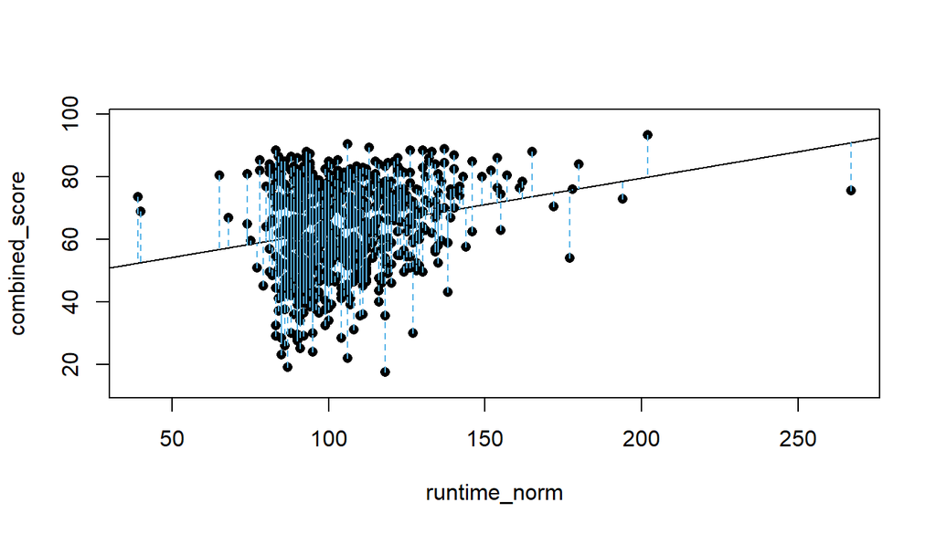

```
## Click two points to make a line.

## Call:
## lm(formula = y ~ x, data = pts)
##
## Coefficients:
## (Intercept)            x
##      45.765        0.169
##
## Sum of Squares:  140228
```

```r
#data pre-processing
mean_runtime<-movies%>%
  filter(!is.na(runtime))%>%
  summarise(mean(runtime))

movies<-movies%>%
  mutate(runtime_norm=ifelse(!is.na(runtime), runtime, as.numeric(mean_runtime)))

#a scatter plot
plot_ss(x=runtime_norm, y=combined_score, data=movies)
```

```r
#model for 1 variable
m_runtime <- lm(combined_score ~ runtime_norm, data = movies)
summary(m_runtime)
```

```
##
## Call:
## lm(formula = combined_score ~ runtime_norm, data = movies)
##
## Residuals:
##     Min      1Q  Median      3Q     Max
## -48.205 -10.610   1.268  12.327  28.710
##
## Coefficients:
##              Estimate Std. Error t value Pr(>|t|)
## (Intercept)  45.76467    3.19247  14.335  < 2e-16 ***
## runtime_norm  0.16898    0.02967   5.695 1.87e-08 ***
## ---
## Signif. codes:  0 '***' 0.001 '**' 0.01 '*' 0.05 '.' 0.1 ' ' 1
##
## Residual standard error: 14.7 on 649 degrees of freedom
## Multiple R-squared:  0.04759,    Adjusted R-squared:  0.04612
## F-statistic: 32.43 on 1 and 649 DF,  p-value: 1.873e-08
```

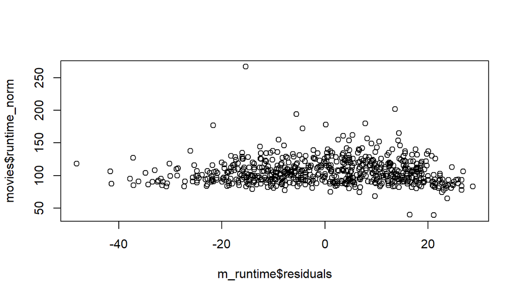

```r
#linear relation check
plot(m_runtime$residuals, movies$runtime_norm)
```

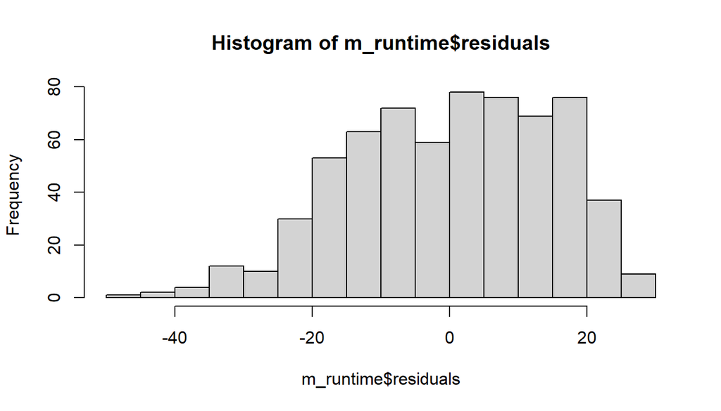

```r
#nearly normal residuals check
hist(m_runtime$residuals)
```

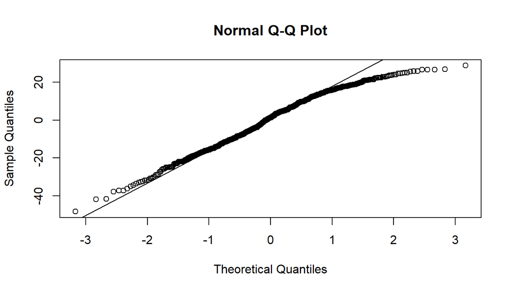

```r
qqnorm(m_runtime$residuals)
qqline(m_runtime$residuals)
```

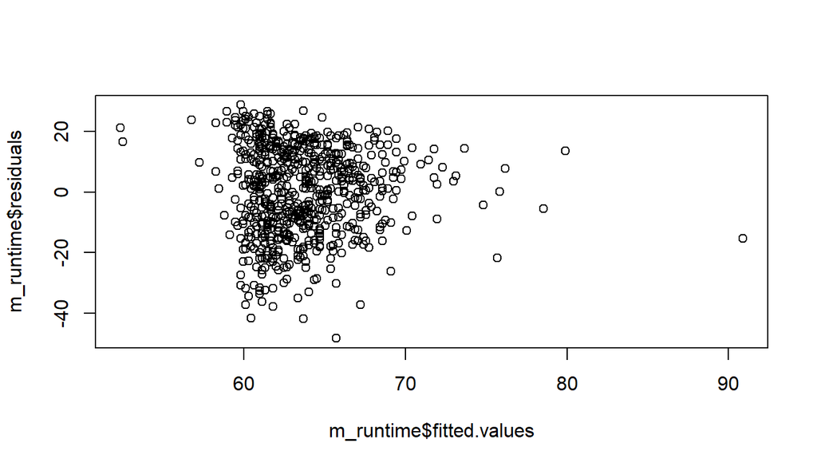

```r
#constant variability check
plot(m_runtime$residuals ~ m_runtime$fitted.values)
```

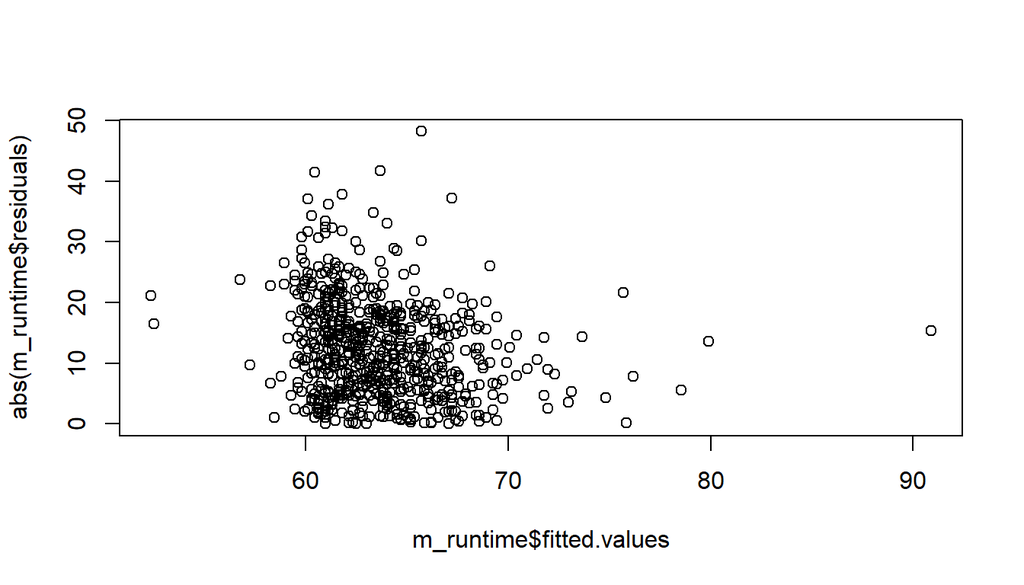

```r
plot(abs(m_runtime$residuals) ~ m_runtime$fitted.values)
```

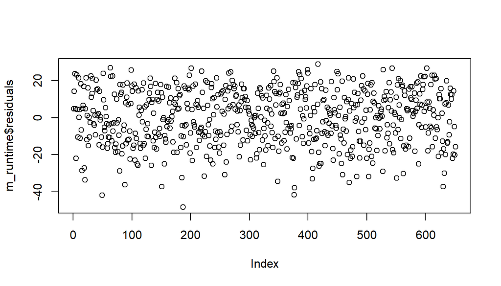

```r
#independent observations check
plot(m_runtime$residuals)
```

Conclusion: moderately fit to unfit,  
left skewed residuals distribution and not convincing linearity

### critics_score

```r
critics_score_assessment = assess_variable(movies$critics_score)
critics_score_assessment
```

```
## $num_subcats
## [1] 99
##
## $subcats
##  [1]  45  96  91  80  33  57  17  90  83  89  67  25  15  78  54  61  19  29  40
## [20]  92  66  47  79  51  77  68  69  52  76  13  98  81  21  88  50  35  73  27
## [39]  34  84  44  46  56   6  64  43  12 100  75  63  24  65  48  59  60  71  32
## [58]  82  42  70   9  62  95  93  86  39  22  14  97  38   4   3  36  37  74  55
## [77]  53  41  85  94  72  31  11  10  30  23   7  28  58  87  20   2  18   1   5
## [96]   8  16  49  26
##
## $coverage
## [1] 1
```

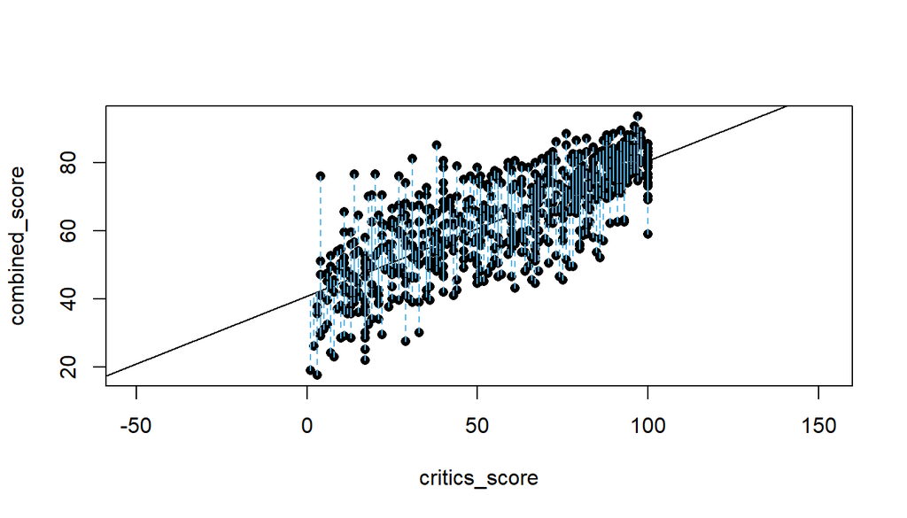

```
## Click two points to make a line.

## Call:
## lm(formula = y ~ x, data = pts)
##
## Coefficients:
## (Intercept)            x
##     40.7556       0.3968
##
## Sum of Squares:  64669.46
```

```r
#a scatter plot
plot_ss(x=critics_score, y=combined_score, data=movies)
```

```r
#model for 1 variable
m_critics_score <- lm(combined_score ~ critics_score, data = movies)
summary(m_critics_score)
```

```
##
## Call:
## lm(formula = combined_score ~ critics_score, data = movies)
##
## Residuals:
##     Min      1Q  Median      3Q     Max
## -25.501  -6.441   0.190   6.801  33.657
##
## Coefficients:
##               Estimate Std. Error t value Pr(>|t|)
## (Intercept)   40.75561    0.88626   45.99   <2e-16 ***
## critics_score  0.39681    0.01379   28.79   <2e-16 ***
## ---
## Signif. codes:  0 '***' 0.001 '**' 0.01 '*' 0.05 '.' 0.1 ' ' 1
##
## Residual standard error: 9.982 on 649 degrees of freedom
## Multiple R-squared:  0.5608, Adjusted R-squared:  0.5601
## F-statistic: 828.6 on 1 and 649 DF,  p-value: < 2.2e-16
```

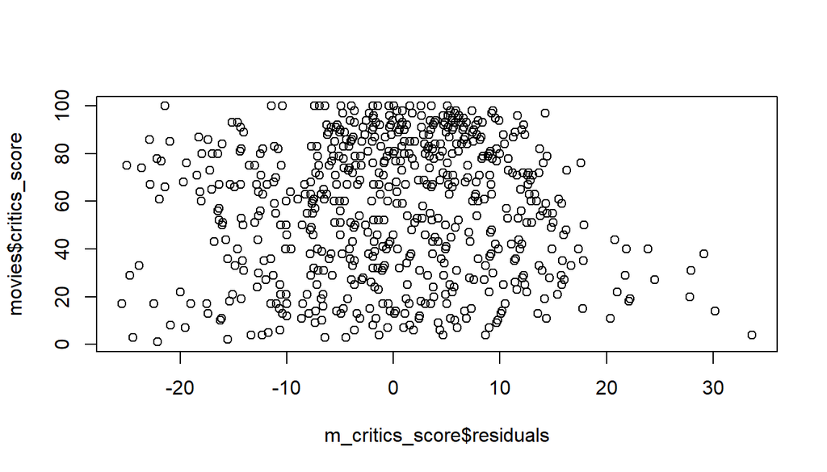

```r
#linear relation check
plot(m_critics_score$residuals, movies$critics_score)
```

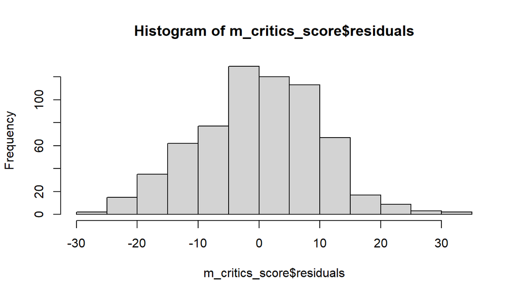

```r
#nearly normal residuals check
hist(m_critics_score$residuals)
```

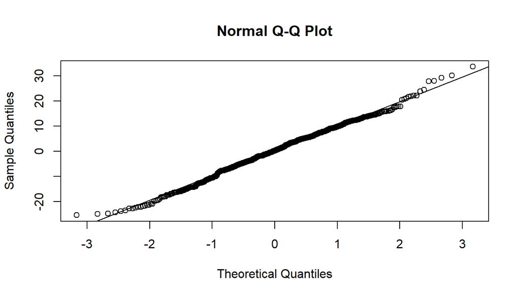

```r
qqnorm(m_critics_score$residuals)
qqline(m_critics_score$residuals)
```

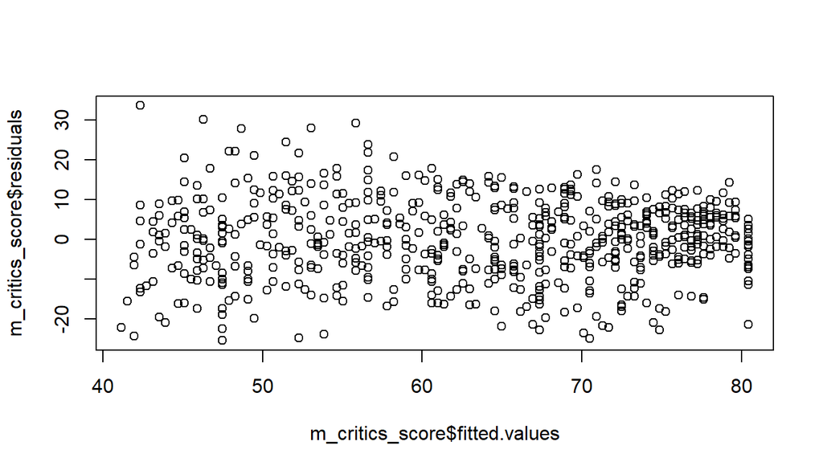

```r
#constant variability check
plot(m_critics_score$residuals ~ m_critics_score$fitted.values)
```

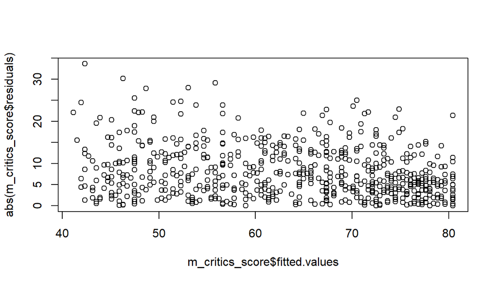

```r
plot(abs(m_critics_score$residuals) ~ m_critics_score$fitted.values)
```

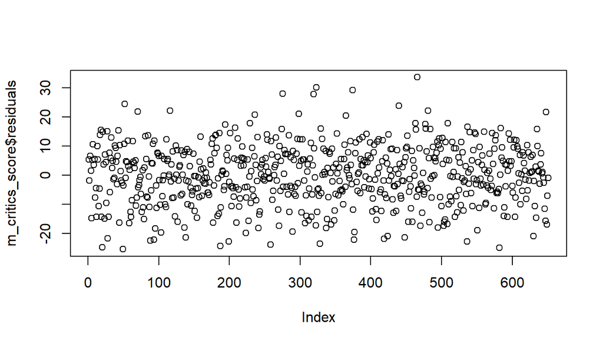

```r
#independent observations check
plot(m_critics_score$residuals)
```

Conclusion: fit,  
normal residuals, fair linearity, constant variability

### best_pic_nom

```r
#model for 1 variable

best_pic_nom_assessed = assess_variable(movies$best_pic_nom)
best_pic_nom_assessed
```

```
## $num_subcats
## [1] 2
##
## $subcats
## [1] no  yes
## Levels: no yes
##
## $coverage
## [1] 1
```

```r
m_best_pic_nom <- lm(combined_score ~ best_pic_nom, data = movies)
summary(m_best_pic_nom)
```

```
##
## Call:
## lm(formula = combined_score ~ best_pic_nom, data = movies)
##
## Residuals:
##     Min      1Q  Median      3Q     Max
## -45.525 -10.525   1.475  12.033  27.475
##
## Coefficients:
##                 Estimate Std. Error t value Pr(>|t|)
## (Intercept)      63.0254     0.5857  107.60  < 2e-16 ***
## best_pic_nomyes  18.3837     3.1862    5.77 1.23e-08 ***
## ---
## Signif. codes:  0 '***' 0.001 '**' 0.01 '*' 0.05 '.' 0.1 ' ' 1
##
## Residual standard error: 14.69 on 649 degrees of freedom
## Multiple R-squared:  0.04879,    Adjusted R-squared:  0.04733
## F-statistic: 33.29 on 1 and 649 DF,  p-value: 1.23e-08
```

Conclusion: unfit,  
very low R^2 (explained variability)

### Combination of critics_score and best_pic_nom to ensure previous conclusion

```r
m_best_pic_nom_critics <- lm(combined_score ~ critics_score, best_pic_nom, data = movies)
summary(m_best_pic_nom_critics)
```

```
##
## Call:
## lm(formula = combined_score ~ critics_score, data = movies, subset = best_pic_nom)
##
## Residuals:
##        Min         1Q     Median         3Q        Max
## -2.187e-11  3.520e-14  3.520e-14  3.520e-14  3.520e-14
##
## Coefficients:
##                Estimate Std. Error   t value Pr(>|t|)
## (Intercept)   5.253e+01  1.740e-13 3.019e+14   <2e-16 ***
## critics_score 2.549e-01  3.654e-15 6.976e+13   <2e-16 ***
## ---
## Signif. codes:  0 '***' 0.001 '**' 0.01 '*' 0.05 '.' 0.1 ' ' 1
##
## Residual standard error: 8.592e-13 on 649 degrees of freedom
## Multiple R-squared:      1,  Adjusted R-squared:      1
## F-statistic: 4.866e+27 on 1 and 649 DF,  p-value: < 2.2e-16
```

Conclusion:  
R^2=1, an over-fit sign, rejecting this variant

### best_pic_win

```r
best_pic_win_assessed = assess_variable(movies$best_pic_win)
best_pic_win_assessed
```

```
## $num_subcats
## [1] 2
##
## $subcats
## [1] no  yes
## Levels: no yes
##
## $coverage
## [1] 1
```

```r
m_best_pic_win <- lm(combined_score ~ best_pic_win, data = movies)
summary(m_best_pic_win)
```

```
##
## Call:
## lm(formula = combined_score ~ best_pic_win, data = movies)
##
## Residuals:
##     Min      1Q  Median      3Q     Max
## -45.949 -10.949   1.551  12.551  27.051
##
## Coefficients:
##                 Estimate Std. Error t value Pr(>|t|)
## (Intercept)      63.4488     0.5888 107.763  < 2e-16 ***
## best_pic_winyes  18.4084     5.6780   3.242  0.00125 **
## ---
## Signif. codes:  0 '***' 0.001 '**' 0.01 '*' 0.05 '.' 0.1 ' ' 1
##
## Residual standard error: 14.94 on 649 degrees of freedom
## Multiple R-squared:  0.01594,    Adjusted R-squared:  0.01442
## F-statistic: 10.51 on 1 and 649 DF,  p-value: 0.001247
```

Conclusion: unfit,  
very low R^2 (explained variability)

### Combination of critics_score and best_pic_win to ensure previous conclusion

```r
m_best_pic_win_critics <- lm(combined_score ~ critics_score, best_pic_win, data = movies)
summary(m_best_pic_win_critics)
```

```
##
## Call:
## lm(formula = combined_score ~ critics_score, data = movies, subset = best_pic_win)
##
## Residuals:
##        Min         1Q     Median         3Q        Max
## -2.259e-11  3.500e-14  3.500e-14  3.500e-14  9.770e-14
##
## Coefficients:
##                Estimate Std. Error   t value Pr(>|t|)
## (Intercept)   5.253e+01  3.032e-13 1.732e+14   <2e-16 ***
## critics_score 2.549e-01  6.613e-15 3.854e+13   <2e-16 ***
## ---
## Signif. codes:  0 '***' 0.001 '**' 0.01 '*' 0.05 '.' 0.1 ' ' 1
##
## Residual standard error: 8.876e-13 on 649 degrees of freedom
## Multiple R-squared:      1,  Adjusted R-squared:      1
## F-statistic: 1.486e+27 on 1 and 649 DF,  p-value: < 2.2e-16
```

Conclusion:  
R^2=1, an over-fit sign, rejecting this variant

### best_dir_win

```r
best_dir_win_assessed = assess_variable(movies$best_dir_win)
best_dir_win_assessed
```

```
## $num_subcats
## [1] 2
##
## $subcats
## [1] no  yes
## Levels: no yes
##
## $coverage
## [1] 1
```

```r
m_best_dir_win <- lm(combined_score ~ best_dir_win, data = movies)
summary(m_best_dir_win)
```

```
##
## Call:
## lm(formula = combined_score ~ best_dir_win, data = movies)
##
## Residuals:
##    Min     1Q Median     3Q    Max
## -45.70 -11.20   1.80  12.55  27.30
##
## Coefficients:
##                 Estimate Std. Error t value Pr(>|t|)
## (Intercept)       63.200      0.607 104.115  < 2e-16 ***
## best_dir_winyes    6.765      2.362   2.864  0.00431 **
## ---
## Signif. codes:  0 '***' 0.001 '**' 0.01 '*' 0.05 '.' 0.1 ' ' 1
##
## Residual standard error: 14.97 on 649 degrees of freedom
## Multiple R-squared:  0.01248,    Adjusted R-squared:  0.01096
## F-statistic: 8.204 on 1 and 649 DF,  p-value: 0.004314
```

Conclusion: unfit,  
very low R^2 (explained variability)

### Combination of critics_score and best_dir_win to ensure previous conclusion

```r
m_best_dir_win_critics <- lm(combined_score ~ critics_score, best_dir_win, data = movies)
summary(m_best_dir_win_critics)
```

```
##
## Call:
## lm(formula = combined_score ~ critics_score, data = movies, subset = best_dir_win)
##
## Residuals:
##        Min         1Q     Median         3Q        Max
## -2.233e-11  3.720e-14  3.720e-14  3.720e-14  3.720e-14
##
## Coefficients:
##                Estimate Std. Error  t value Pr(>|t|)
## (Intercept)   5.253e+01  1.357e-13 3.87e+14   <2e-16 ***
## critics_score 2.549e-01  2.715e-15 9.39e+13   <2e-16 ***
## ---
## Signif. codes:  0 '***' 0.001 '**' 0.01 '*' 0.05 '.' 0.1 ' ' 1
##
## Residual standard error: 8.773e-13 on 649 degrees of freedom
## Multiple R-squared:      1,  Adjusted R-squared:      1
## F-statistic: 8.818e+27 on 1 and 649 DF,  p-value: < 2.2e-16
```

Conclusion:  
R^2=1, an over-fit sign, rejecting this variant

### Alalyze multi-leveled categories (more than 10 levels)

Figure whether different categorical vars could serve as predictors for that sample

```r
length(unique(movies$director))
```

```
## [1] 533
```

```r
length(unique(movies$actor1))
```

```
## [1] 486
```

```r
length(unique(movies$actor2))
```

```
## [1] 573
```

```r
length(unique(movies$actor3))
```

```
## [1] 602
```

```r
length(unique(movies$actor4))
```

```
## [1] 608
```

```r
length(unique(movies$actor5))
```

```
## [1] 616
```

Conclusion:  
Those categories (director, actor1-5) are unlikely to produce reliable prediction, cause their unique values number is  
very high (relatively to the sample size) and thus they could not be used.

Unfortunately this course did not handle the subject of over-fit  
And most of the categorical variables here lead to over-fit (R^2==1)  
(over-fit, that will show itself on population scale)

I leave only critics_score cause it is answering all the conditions for the linear regression  
and provides 56% of the explained variability without the risk of overfit.

## Part 5: Prediction

```r
predictions<-vector("numeric", length(10))
critics_scores<-vector("numeric", length(10))

for(i in 1:10){
   new_movie <-data.frame(year="2016", critics_score=i*10)
   prediction=predict(m_critics_score,new_movie)
   interval_prediction=predict(m_critics_score, new_movie, interval = "prediction", level = 0.95)
   print(interval_prediction)
   predictions[i]<-prediction
   critics_scores[i]<-i*10
}
```

```
##        fit      lwr      upr
## 1 44.72369 25.06486 64.38251
##        fit      lwr      upr
## 1 48.69176 29.04885 68.33467
##        fit      lwr      upr
## 1 52.65983 33.02912 72.29054
##       fit      lwr      upr
## 1 56.6279 37.00566 76.25015
##        fit      lwr      upr
## 1 60.59598 40.97847 80.21348
##        fit      lwr      upr
## 1 64.56405 44.94755 84.18055
##        fit      lwr      upr
## 1 68.53212 48.91289 88.15135
##        fit     lwr      upr
## 1 72.50019 52.8745 92.12589
##        fit      lwr      upr
## 1 76.46826 56.83237 96.10416
##        fit      lwr      upr
## 1 80.43634 60.78653 100.0861
```

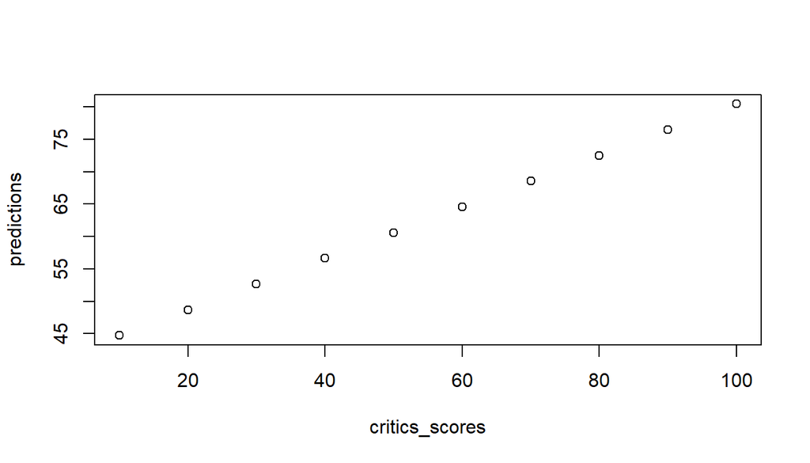

```r
plot(x=critics_scores, y=predictions)
```

Above you can observe predictions with CI 95%  
They looks logically correct (for increased critics_score)

## Part 6: Conclusion

I found only one strong and reliable predictor:critics_score  
The rest - categorical predictors - are doubtful, while they lead to model over-fit  
This over-fit will be sensible if real (population) data used for testing the model.  
(This subject was not explained in the course, unfortunately)

With CI 95% my model reliably predicts the score (I created combined score from IMDB and RT scores on the way)